# Assignment 10: Predictive Modeling - Part 1

*How to do it?*:

- Open the Rmarkdown file of this assignment (link) in Rstudio.
- Right under each **question**, insert a code chunk (you can use the hotkey `Ctrl + Alt + I` to add a code chunk) and code the solution for the question.
- `Knit` the rmarkdown file (hotkey: `Ctrl + Alt + K`) to export an html.
- Publish the html file to your Githiub Page.

*Submission*: Submit the link on Github of the assignment to Canvas

1. Use the `Adult Census Income` dataset. We will predict the income (whether or not it is more than 50k or not) of an adult. Import the dataset. Partition the data into 80% training and 20% testing.

```r
library(tidyverse)
library(dplyr)
library(caret)
df <- read_csv('adult_census.csv')
```

```r
df <- df %>% rename(target=income)

df <- df %>%
  mutate(target = as.factor(target))

set.seed(2020)
splitIndex <- createDataPartition(df$target, p = .80, list = FALSE)
df_train <- df[splitIndex,]
df_test <- df[-splitIndex,]
```

2. Practice Decision Tree. Do the follows:
- Use `rpart` package, create a decision tree with maximum depth of 3.

```r
library(rpart)
tree <- rpart(target ~ ., data = df_train, control = rpart.control(maxdepth = 3))
```

- Calculate the accuracy of the model on the testing data. Notice that the positive outcome here is not `1` but `>50K` or `<50K`.

```r
prediction <- predict(tree, df_test, type = "class")
confmatrix <- confusionMatrix(data = prediction, reference = df_test$target)
confmatrix$overall[1]
```

```
##  Accuracy
## 0.8387592
```

- Plot the tree

```r
library(rattle)
```

[figure not shown]

```r
fancyRpartPlot(tree)
```

- Plot the variable importance by the tree

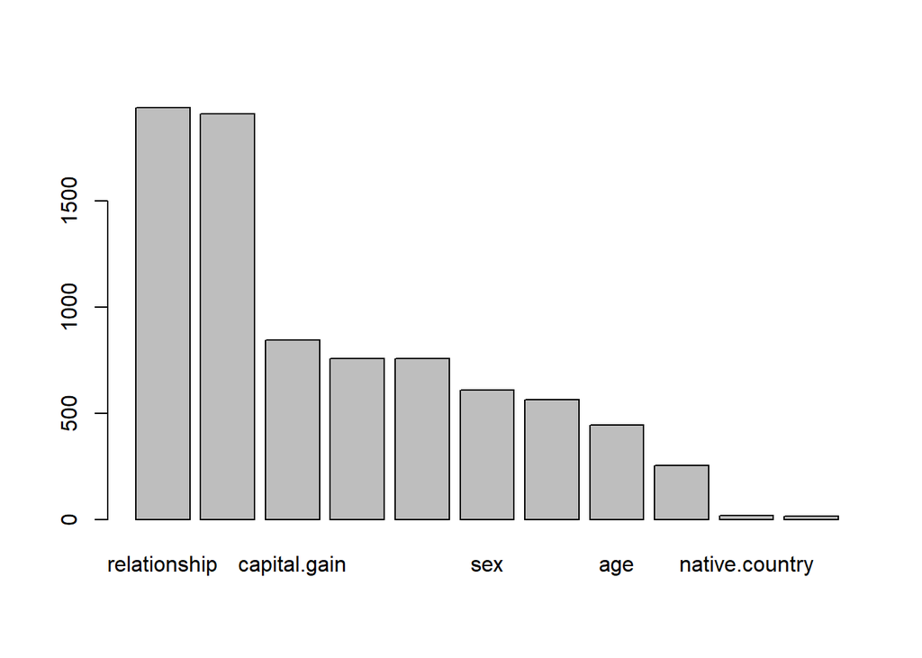

```r
barplot(tree$variable.importance)
```

3. Create 3 more trees and compare the testing accuracy of these trees, which tree give the highest testing accuracy.

```r
tree2 <- rpart(target ~ ., data = df_train, control = rpart.control(maxdepth = 10))

prediction2 <- predict(tree2, df_test, type = "class")
confmatrix2 <- confusionMatrix(data = prediction2, reference = df_test$target)
confmatrix2$overall[1]
```

```
##  Accuracy
## 0.8387592
```

```r
tree3 <- rpart(target ~ ., data = df_train, control = rpart.control(maxdepth = 2))

prediction3 <- predict(tree3, df_test, type = "class")
confmatrix3 <- confusionMatrix(data = prediction3, reference = df_test$target)
confmatrix3$overall[1]
```

```
##  Accuracy
## 0.8264742
```

```r
tree4 <- rpart(target ~ ., data = df_train, control = rpart.control(maxdepth = 30)) #this is the maximum that it allows

prediction4 <- predict(tree4, df_test, type = "class")
confmatrix4 <- confusionMatrix(data = prediction4, reference = df_test$target)
confmatrix4$overall[1]
```

```
##  Accuracy
## 0.8387592
```

Trees 2 and 4 had the highest accuracies at 0.839, which is the same accuracy as the original tree. This seems to be the maximum accuracy for this specific split. Tree 3 had a lower mex depth, causing it to be less accuarte.

4. Practice Random Forest. Do the follows:
- Use `randomForest` package, create a random forest of 1000 trees.
- Calculate the accuracy of the model on the testing data.

```r
library(randomForest)
forest = randomForest(target ~ ., data=df_train, ntree = 1000)

prediction5 <- predict(forest, df_test, type = "class")
confmatrix5 <- confusionMatrix(data = prediction5, reference = df_test$target)
confmatrix5$overall[1]
```

```
##  Accuracy
## 0.8588759
```

5. Create 3 more forests and compare the testing accuracy of these forests, which forest give the highest testing accuracy.

```r
forest2 = randomForest(target ~ ., data=df_train, ntree = 5000)

prediction6 <- predict(forest2, df_test, type = "class")
confmatrix6 <- confusionMatrix(data = prediction6, reference = df_test$target)
confmatrix6$overall[1]
```

```
##  Accuracy
## 0.8596437
```

```r
forest3 = randomForest(target ~ ., data=df_train, ntree = 100)

prediction7 <- predict(forest3, df_test, type = "class")
confmatrix7 <- confusionMatrix(data = prediction7, reference = df_test$target)
confmatrix7$overall[1]
```

```
##  Accuracy
## 0.8584152
```

```r
forest4 = randomForest(target ~ ., data=df_train, ntree = 2500)

prediction8 <- predict(forest4, df_test, type = "class")
confmatrix8 <- confusionMatrix(data = prediction8, reference = df_test$target)
confmatrix8$overall[1]
```

```
##  Accuracy
## 0.8593366
```

6. What is the best model (in term of testing accuracy) among all models (including trees and forests) you have trained?